# Stat 371 Homework #7. Due Sunday Oct. 25 11:59 pm

## 3.1 `Step 1`. State null and alternative hypotheses

1. `Claim`: “the population mean of milk production using the new feed additive and using the old diet are different.”
2. The random variables involved in the claim are:

$$\begin{align}
X_1:&\; \textrm{Production of milk using the new feed additive}\\
X_2:&\; \textrm{Production of milk using the old feed additive}\\
X_1-X_2:&\; \textrm{Difference in production of milk using the new feed additive and the old feed additive}
\end{align}$$

3. The parameter of interest

Let $\mu_{new}$ and $\mu_{old}$ be the population mean milk productions for the new and old diets, respectively.

$$\begin{align}
\textrm{Variable}\; X_1:&\; \textrm{The parameter is}\; \mu_1\; \textrm{or}\;\mu_{\textrm{new}}. \\
\textrm{Variable}\; X_2:&\; \textrm{The parameter is}\; \mu_2\;\mu_{\textrm{old}}. \\
X_1-X_2:&\; \textrm{the parameter population mean difference is}\; \mu_1- \mu_2 \;\textrm{or}\; \mu_{\textrm{new}} - \mu_{\textrm{old}}
\end{align}$$

Or, equivalently:

$$\bbox[#ffcc99,20px,border:10px ligth red]
{
H_{0}: \mu_{\textrm{new}} - \mu_{\textrm{old}} = 0 \;\;\textrm{vs}\;\;H_{A}: \mu_{\textrm{new}} - \mu_{\textrm{old}} \ne 0
}$$

## 3.2 `Step 2`. Data Exploration

- Read the data

```r
new<-c( 57, 45, 48, 39, 49)

old<-c(43, 51, 44, 47, 38, 46, 40, 35)
```

### 3.2.1 Statistical summary

```r
length(new)
```

```
## [1] 5
```

```r
length(old)
```

```
## [1] 8
```

```r
summary(new)
```

```
##    Min. 1st Qu.  Median    Mean 3rd Qu.    Max.
##    39.0    45.0    48.0    47.6    49.0    57.0
```

```r
summary(old)
```

```
##    Min. 1st Qu.  Median    Mean 3rd Qu.    Max.
##   35.00   39.50   43.50   43.00   46.25   51.00
```

```r
sd(new)
```

```
## [1] 6.542171
```

```r
sd(old)
```

```
## [1] 5.182388
```

The table below contains summary statistics for the two datasets.

| Group | n | Min | Max | Mean | SD | 1st Q | Median | 3rd Q |
| --- | --- | --- | --- | --- | --- | --- | --- | --- |
| New | 5 | 39.0 | 57.0 | 47.6 | 6.54 | 45.0 | 48.0 | 49.0 |
| Old | 8 | 35 | 51 | 43.00 | 5.18 | 39.50 | 43.50 | 46.25 |

`Interpretation:`

We observe that the new diet has milk production between 39 and 57 pounds, an average weight of 47.6 pounds, and sd=6.54 pounds. On the other hand, the old diet has milk production between 35 and 51 pounds, an average weight of 43 pounds, and sd=5.18. It looks like a new diet has a high average milk production than the old diet.

### 3.2.2 Graphical summary

#### 3.2.2.1 1. Histogram

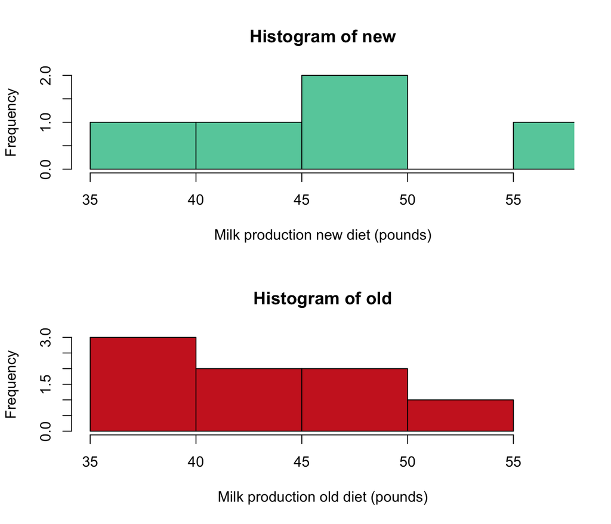

```r
par(mfrow=c(2,1))

hist(new,col="aquamarine3",xlim = c(35,57),xlab="Milk production new diet (pounds)")
hist(old,col="firebrick3 ",xlim = c(35,57),xlab="Milk production old diet (pounds)")
```

#### 3.2.2.2 2. Dot plot

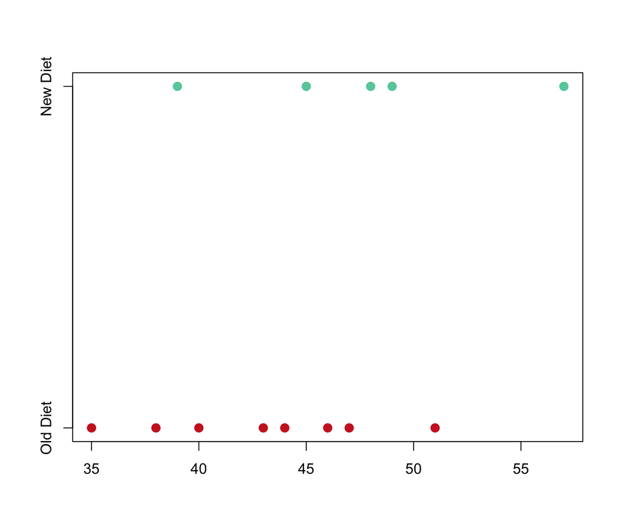

```r
x <- list("Old Diet"=old, "New Diet"=new)

stripchart(x,col=c("firebrick3","aquamarine3"),pch=16,cex=1.4)
```

#### 3.2.2.3 3. Boxplot

Before drawing a side by side boxplot, we need to rearrange the data as follow:

```r
all <- c(old,new)
group <- c(rep("Old Diet",8),rep("New Diet", 5))
```

Now we can make a side-by-side boxplot.

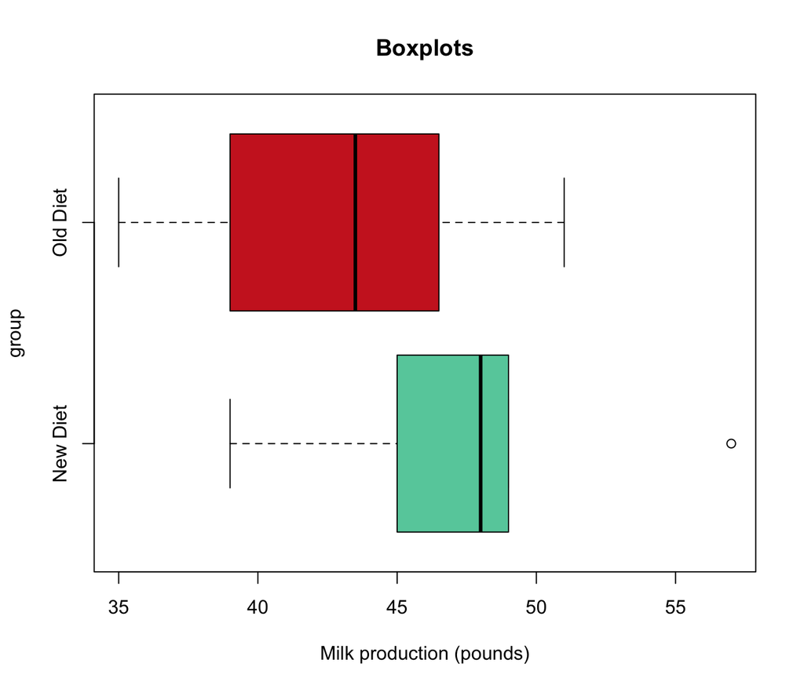

```r
#side by side boxplots

boxplot(all ~ group, main = "Boxplots", xlab = "Milk production (pounds)",col=c("aquamarine3","firebrick3"),horizontal=TRUE)
```

We can see in this boxplot, as we did in the histogram and dot plot, that the average milk production with the new diet seems generally higher than the average milk production with the old diet. Also, there is an outlier in milk production with the new diet.

The spread also seems about the same. Again, with a small number of points, boxplots may hide the individual data points’ essential features, and a dot plot might be better.

## 3.3 `Step 3`. Check assumptions

Now that we have explored the data, we check the assumptions.

- `Are the two samples simple random samples?`

Yes.

- `Do the two populations are independent?`

We can validate this assumption from the study since the researcher chooses 13 cows at random from a large population. Then she randomly assigns $n_{old} = 8$ to the old diet and $n_{new} = 5$ to a new diet including the additive. The `randomization guarantees the independence of the populations.`

- `Do the two populations data milk production with the new diet and milk production with the old diet follow a normal distribution?`

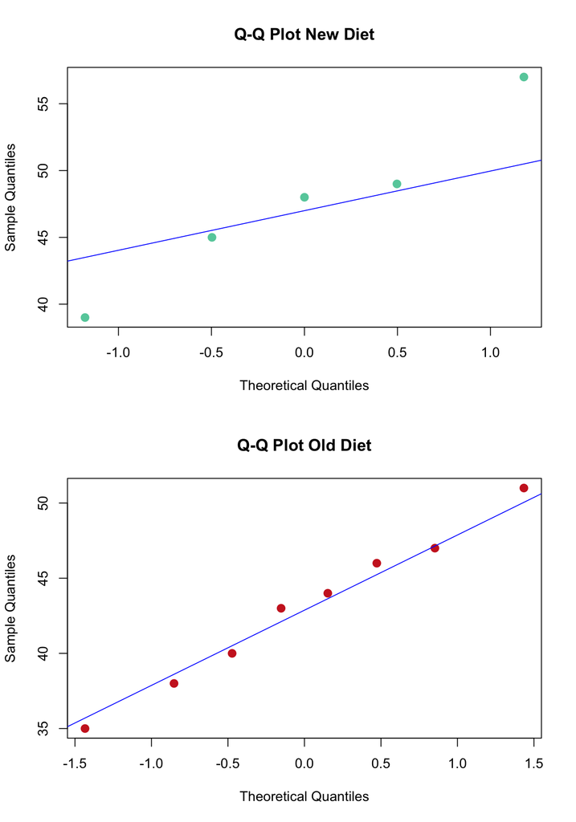

```r
par(mfrow=c(2,1))

qqnorm(new,col="aquamarine3",pch=16,cex=1.4,main = "Q-Q Plot New Diet")
qqline(new,col="blue")

qqnorm(old,col="firebrick3",pch=16,cex=1.4,main = "Q-Q Plot Old Diet")
qqline(old,col="blue")
```

`Interpretation` From the two QQ plots, we can reasonably assume that both sample milk production with the two diets comes from normal populations.

### 3.3.1 D. Homogeneity of Variance

Are the variance of the data milk production under the new diet and the old diet the same?.

- Use the rule of thumb: it is reasonable to assume equal population variances if the ratio of two sample standard deviations is between 0.5 and 2.

```r
sd(new)
```

```
## [1] 6.542171
```

```r
sd(old)
```

```
## [1] 5.182388
```

```r
sd(new)/sd(old)
```

```
## [1] 1.262385
```

`Interpretation:`

Since the ratio $\frac{sd(new)}{sd(old)}=1.2623854$ of the two sample standard deviations is between 0.5 and 2, we can assume the two populations of milk production under the new diet, and the old diet has equal population variances.

## 3.4 `Step 4`. Perform the appropriate Test

```r
t.test(x=new, y =old,
       alternative = "two.sided",
       mu = 0, paired = FALSE, var.equal = TRUE,
       conf.level = 0.98)
```

```
##
##  Two Sample t-test
##
## data:  new and old
## t = 1.412, df = 11, p-value = 0.1856
## alternative hypothesis: true difference in means is not equal to 0
## 98 percent confidence interval:
##  -4.254736 13.454736
## sample estimates:
## mean of x mean of y
##      47.6      43.0
```

Interpretation

- The observed t statistics is $t = 1.412$
- `P value:` The p-value of the test is $p=0.1856$, which is greater than $\alpha=0.02$. Thus, we have sufficient evidence to `do not reject` the null hypothesis at the $\alpha=0.02$ level.
- `Confidence interval:` The $98\%$ two-sided confidence interval for the true difference in mean milk production between the new diet and the old diet is $(-4.254736, 13.454736)$ pounds. Since this interval includes $0$ as a likely value for the true difference in means, we have evidence to do not reject the null hypothesis at the $\alpha=0.02$ level.